# (Prosper Loan Data)

## Preliminary Wrangling

> > This data about Prosper Marketplace, Inc. is a San Francisco, California-based company in the peer-to-peer lending industry. Prosper Funding LLC, one of its subsidiaries, operates Prosper.com, a website where individuals can either invest in personal loans or request to borrow money. The data contain 113937 raw and 81 columns.

```python
# import all packages and set plots to be embedded inline
import numpy as np
import pandas as pd
import matplotlib.pyplot as plt
import seaborn as sb

%matplotlib inline
import warnings
warnings.filterwarnings("ignore")
```

```python
df = pd.read_csv('prosperLoanData.csv')
df.head()
```

|  | ListingKey | ListingNumber | ListingCreationDate | CreditGrade | Term | LoanStatus | ClosedDate | BorrowerAPR | BorrowerRate | LenderYield | ... | LP_ServiceFees | LP_CollectionFees | LP_GrossPrincipalLoss | LP_NetPrincipalLoss | LP_NonPrincipalRecoverypayments | PercentFunded | Recommendations | InvestmentFromFriendsCount | InvestmentFromFriendsAmount | Investors |
| --- | --- | --- | --- | --- | --- | --- | --- | --- | --- | --- | --- | --- | --- | --- | --- | --- | --- | --- | --- | --- | --- |
| 0 | 1021339766868145413AB3B | 193129 | 2007-08-26 19:09:29.263000000 | C | 36 | Completed | 2009-08-14 00:00:00 | 0.16516 | 0.1580 | 0.1380 | ... | -133.18 | 0.0 | 0.0 | 0.0 | 0.0 | 1.0 | 0 | 0 | 0.0 | 258 |
| 1 | 10273602499503308B223C1 | 1209647 | 2014-02-27 08:28:07.900000000 | NaN | 36 | Current | NaN | 0.12016 | 0.0920 | 0.0820 | ... | 0.00 | 0.0 | 0.0 | 0.0 | 0.0 | 1.0 | 0 | 0 | 0.0 | 1 |
| 2 | 0EE9337825851032864889A | 81716 | 2007-01-05 15:00:47.090000000 | HR | 36 | Completed | 2009-12-17 00:00:00 | 0.28269 | 0.2750 | 0.2400 | ... | -24.20 | 0.0 | 0.0 | 0.0 | 0.0 | 1.0 | 0 | 0 | 0.0 | 41 |
| 3 | 0EF5356002482715299901A | 658116 | 2012-10-22 11:02:35.010000000 | NaN | 36 | Current | NaN | 0.12528 | 0.0974 | 0.0874 | ... | -108.01 | 0.0 | 0.0 | 0.0 | 0.0 | 1.0 | 0 | 0 | 0.0 | 158 |
| 4 | 0F023589499656230C5E3E2 | 909464 | 2013-09-14 18:38:39.097000000 | NaN | 36 | Current | NaN | 0.24614 | 0.2085 | 0.1985 | ... | -60.27 | 0.0 | 0.0 | 0.0 | 0.0 | 1.0 | 0 | 0 | 0.0 | 20 |

5 rows × 81 columns

```python
df.shape
```

```
(113937, 81)
```

There is a lot of data rows and a lot of columns that have much Null value, so I choose specific columns I work on it and drop all of the others

```python
# The cols name that i work on it
cols = ['Term','LoanStatus','ListingCategory (numeric)','EmploymentStatus','IsBorrowerHomeowner',
        'CreditScoreRangeLower','CreditScoreRangeUpper','StatedMonthlyIncome','LoanOriginalAmount','MonthlyLoanPayment']
```

```python
# filter the data on that cols and save it in a new dataframe colled new_df
new_df = df[cols]
new_df.head()
```

|  | Term | LoanStatus | ListingCategory (numeric) | EmploymentStatus | IsBorrowerHomeowner | CreditScoreRangeLower | CreditScoreRangeUpper | StatedMonthlyIncome | LoanOriginalAmount | MonthlyLoanPayment |
| --- | --- | --- | --- | --- | --- | --- | --- | --- | --- | --- |
| 0 | 36 | Completed | 0 | Self-employed | True | 640.0 | 659.0 | 3083.333333 | 9425 | 330.43 |
| 1 | 36 | Current | 2 | Employed | False | 680.0 | 699.0 | 6125.000000 | 10000 | 318.93 |
| 2 | 36 | Completed | 0 | Not available | False | 480.0 | 499.0 | 2083.333333 | 3001 | 123.32 |
| 3 | 36 | Current | 16 | Employed | True | 800.0 | 819.0 | 2875.000000 | 10000 | 321.45 |
| 4 | 36 | Current | 2 | Employed | True | 680.0 | 699.0 | 9583.333333 | 15000 | 563.97 |

```python
new_df.info()
```

```
<class 'pandas.core.frame.DataFrame'>
RangeIndex: 113937 entries, 0 to 113936
Data columns (total 10 columns):
 #   Column                     Non-Null Count   Dtype
---  ------                     --------------   -----
 0   Term                       113937 non-null  int64
 1   LoanStatus                 113937 non-null  object
 2   ListingCategory (numeric)  113937 non-null  int64
 3   EmploymentStatus           111682 non-null  object
 4   IsBorrowerHomeowner        113937 non-null  bool
 5   CreditScoreRangeLower      113346 non-null  float64
 6   CreditScoreRangeUpper      113346 non-null  float64
 7   StatedMonthlyIncome        113937 non-null  float64
 8   LoanOriginalAmount         113937 non-null  int64
 9   MonthlyLoanPayment         113937 non-null  float64
dtypes: bool(1), float64(4), int64(3), object(2)
memory usage: 7.9+ MB
```

#### Define

> `EmploymentStatus` , `CreditScoreRangeLower`, `CreditScoreRangeUpper` have Null value

> > I will replace NaN value in `EmploymentStatus` with "Not available" and i will drop NaN value in `CreditScoreRangeLower` and `CreditScoreRangeUpper`

#### Code

```python
new_df['EmploymentStatus'].fillna("Not available",inplace=True)
new_df.dropna(subset = ["CreditScoreRangeLower"], inplace=True)
```

#### Test

```python
new_df.info()
```

```
<class 'pandas.core.frame.DataFrame'>
Int64Index: 113346 entries, 0 to 113936
Data columns (total 10 columns):
 #   Column                     Non-Null Count   Dtype
---  ------                     --------------   -----
 0   Term                       113346 non-null  int64
 1   LoanStatus                 113346 non-null  object
 2   ListingCategory (numeric)  113346 non-null  int64
 3   EmploymentStatus           113346 non-null  object
 4   IsBorrowerHomeowner        113346 non-null  bool
 5   CreditScoreRangeLower      113346 non-null  float64
 6   CreditScoreRangeUpper      113346 non-null  float64
 7   StatedMonthlyIncome        113346 non-null  float64
 8   LoanOriginalAmount         113346 non-null  int64
 9   MonthlyLoanPayment         113346 non-null  float64
dtypes: bool(1), float64(4), int64(3), object(2)
memory usage: 8.8+ MB
```

#### Define

> I will convert `CreditScoreRangeLower`, `CreditScoreRangeUpper` to one column have its score regard to source in next photo and make it in order format

[figure not shown]

```python
new_df.query('CreditScoreRangeLower < 300').shape[0],new_df.query('CreditScoreRangeUpper < 549').shape[0]
```

```
(133, 2809)
```

```python
new_df.query('CreditScoreRangeLower > 750').shape[0],new_df.query('CreditScoreRangeUpper > 900').shape[0]
```

```
(16089, 0)
```

I will leave the data as it is and make my cluster

#### code

```python
# little fun to cluster score
def Credit_score(x):
    outcome=""
    if x >= 300 :
        outcome = "Poor"
    if x>=550:
        outcome = "Fair"
    if x>=650:
        outcome = "Good"
    if x>=750:
        outcome = "Excellent"
    return outcome
```

```python
new_df['CreditScore'] = new_df['CreditScoreRangeLower'].apply(Credit_score)
```

```python
# Drop the redundant columns
cols = ['CreditScoreRangeLower','CreditScoreRangeUpper']
new_df.drop(columns=cols , axis=1 , inplace=True)
```

```python
order = ['Poor','Fair','Good','Excellent']
order_class = pd.api.types.CategoricalDtype(ordered=True ,categories= order)
new_df['CreditScore'] = new_df['CreditScore'].astype(order_class)
```

#### Test

```python
new_df.head(1)
```

|  | Term | LoanStatus | ListingCategory (numeric) | EmploymentStatus | IsBorrowerHomeowner | StatedMonthlyIncome | LoanOriginalAmount | MonthlyLoanPayment | CreditScore |
| --- | --- | --- | --- | --- | --- | --- | --- | --- | --- |
| 0 | 36 | Completed | 0 | Self-employed | True | 3083.333333 | 9425 | 330.43 | Fair |

#### Define

> replace Term cols from [12,36,60] month to [1,2,3] year

#### Code

```python
def H_M_Yers(x):
    return x/12

new_df['Term'] = new_df['Term'].apply(H_M_Yers).astype(int)
```

#### Test

```python
new_df.head(1)
```

|  | Term | LoanStatus | ListingCategory (numeric) | EmploymentStatus | IsBorrowerHomeowner | StatedMonthlyIncome | LoanOriginalAmount | MonthlyLoanPayment | CreditScore |
| --- | --- | --- | --- | --- | --- | --- | --- | --- | --- |
| 0 | 3 | Completed | 0 | Self-employed | True | 3083.333333 | 9425 | 330.43 | Fair |

#### Define

> Convert `ListingCategory (numeric)` to the corresponding element

> > 0 - Not Available 1 - Debt Consolidation 2 - Home Improvement 3 - Business 4 - Personal Loan 5 - Student Use 6 - Auto 7 - Other 8 - Baby&Adoption 9 - Boat 10 - Cosmetic Procedure 11 - Engagement Ring 12 - Green Loans 13 - Household Expenses 14 - Large Purchases 15 - Medical/Dental 16 - Motorcycle 17 - RV 18 - Taxes 19 - Vacation 20 - Wedding Loans

#### Code

```python
listing_Cat = {0:"Not Available",
               1:"Debt Consolidation",
               2:"Home Improvement",
               3:"Business",
               4:"Personal Loan",
               5:"Student Use",
               6:"Auto",
               7:"Other",
               8:"Baby&Adoption",
               9:"Boat",
               10:"Cosmetic Procedure",
               11:"Engagement Ring",
               12:"Green Loans",
               13:"Household Expenses",
               14:"Large Purchases",
               15:"Medical/Dental",
               16:"Motorcycle",
               17:"RV",
               18:"Taxes",
               19:"Vacation",
               20:"Wedding Loans",}
def Lst_Cat(x,y=listing_Cat):
    return y[x]
new_df.rename(columns={'ListingCategory (numeric)': 'ListingCategory'},inplace=True)
new_df['ListingCategory'] = new_df['ListingCategory'].apply(Lst_Cat)
```

#### Test

```python
new_df.head(2)
```

|  | Term | LoanStatus | ListingCategory | EmploymentStatus | IsBorrowerHomeowner | StatedMonthlyIncome | LoanOriginalAmount | MonthlyLoanPayment | CreditScore |
| --- | --- | --- | --- | --- | --- | --- | --- | --- | --- |
| 0 | 3 | Completed | Not Available | Self-employed | True | 3083.333333 | 9425 | 330.43 | Fair |
| 1 | 3 | Current | Home Improvement | Employed | False | 6125.000000 | 10000 | 318.93 | Good |

```python
new_df.info()
```

```
<class 'pandas.core.frame.DataFrame'>
Int64Index: 113346 entries, 0 to 113936
Data columns (total 9 columns):
 #   Column               Non-Null Count   Dtype
---  ------               --------------   -----
 0   Term                 113346 non-null  int32
 1   LoanStatus           113346 non-null  object
 2   ListingCategory      113346 non-null  object
 3   EmploymentStatus     113346 non-null  object
 4   IsBorrowerHomeowner  113346 non-null  bool
 5   StatedMonthlyIncome  113346 non-null  float64
 6   LoanOriginalAmount   113346 non-null  int64
 7   MonthlyLoanPayment   113346 non-null  float64
 8   CreditScore          113213 non-null  category
dtypes: bool(1), category(1), float64(2), int32(1), int64(1), object(3)
memory usage: 6.7+ MB
```

### What is the structure of your dataset?

> After Cleansing there are 113346 Loans in the dataset with 9 features (Term,LoanStatus,ListingCategory,EmploymentStatus,etc..)with 3 numeric values [`StatedMonthlyIncome`,`LoanOriginalAmount`,`MonthlyLoanPayment`] and one bool [`IsBorrowerHomeowner`] and others are categorical with two with order in nature [`Term`,`CreditScore`]

### What is/are the main feature(s) of interest in your dataset?

> I am interested in factors that affect `Loan Status`

### What features in the dataset do you think will help support your investigation into your feature(s) of interest?

> I think all 8 features will support my investigation. I choose these features because i think it will help

## Univariate Exploration

Let's see the distribution of numeric values [`StatedMonthlyIncome`,`LoanOriginalAmount`,`MonthlyLoanPayment`]

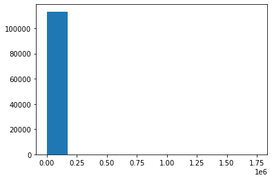

```python
plt.hist(x=new_df.StatedMonthlyIncome);
```

Ohh Nooo a lot of outlier😥let's clean

> i have a question -At what value do I consider this is outlier? I suggest plt a box plot

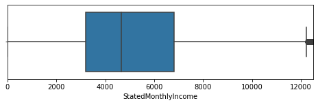

```python
plt.figure(figsize=[8,2])
sb.boxplot(data=new_df,x='StatedMonthlyIncome')
plt.xlim([0,12500]);
```

```python
new_df[new_df['StatedMonthlyIncome']==0]
```

|  | Term | LoanStatus | ListingCategory | EmploymentStatus | IsBorrowerHomeowner | StatedMonthlyIncome | LoanOriginalAmount | MonthlyLoanPayment | CreditScore |
| --- | --- | --- | --- | --- | --- | --- | --- | --- | --- |
| 78 | 3 | Chargedoff | Business | Full-time | True | 0.0 | 4800 | 171.13 | Good |
| 100 | 3 | Chargedoff | Household Expenses | Not employed | False | 0.0 | 4000 | 172.76 | Good |
| 108 | 3 | Completed | Debt Consolidation | Full-time | False | 0.0 | 14000 | 564.07 | Fair |
| 125 | 3 | Current | Other | Not employed | False | 0.0 | 5000 | 217.74 | Fair |
| 170 | 3 | Completed | Other | Not employed | True | 0.0 | 10000 | 397.55 | Excellent |
| ... | ... | ... | ... | ... | ... | ... | ... | ... | ... |
| 113686 | 3 | Completed | Not Available | Full-time | False | 0.0 | 14900 | 560.21 | Good |
| 113761 | 5 | Current | Debt Consolidation | Not employed | False | 0.0 | 7000 | 162.33 | Good |
| 113766 | 3 | Current | Vacation | Not employed | False | 0.0 | 4500 | 144.44 | Good |
| 113767 | 3 | Chargedoff | Business | Self-employed | False | 0.0 | 5000 | 224.77 | Poor |
| 113803 | 3 | Defaulted | Other | Self-employed | True | 0.0 | 5000 | 161.10 | Good |

1388 rows × 9 columns

**There is a 1388 row with not provided State Monthly Income**

> from my position, I think i will drop them , what about you [yes you (reviewer)]

```python
index = new_df[new_df['StatedMonthlyIncome']==0].index
new_df.drop(index,inplace=True)
```

```python
new_df[new_df['StatedMonthlyIncome']>=12500][:3][:]
```

|  | Term | LoanStatus | ListingCategory | EmploymentStatus | IsBorrowerHomeowner | StatedMonthlyIncome | LoanOriginalAmount | MonthlyLoanPayment | CreditScore |
| --- | --- | --- | --- | --- | --- | --- | --- | --- | --- |
| 33 | 3 | Completed | Other | Employed | False | 13083.333333 | 16000 | 500.28 | Excellent |
| 40 | 5 | Current | Debt Consolidation | Self-employed | False | 12750.000000 | 15000 | 374.81 | Good |
| 45 | 5 | Current | Debt Consolidation | Employed | True | 16000.000000 | 25000 | 543.44 | Good |

**There is a 5512 row considered outliers in State Monthly Income**

> i will drop them too

```python
index = new_df[new_df['StatedMonthlyIncome']>=12500].index
new_df.drop(index,inplace=True)
```

Still have over 100K that is good  
Let's plot the distribution for `StatedMonthlyIncome` again

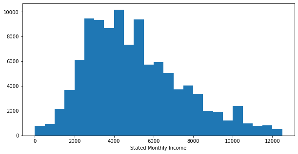

```python
x_bins = np.arange(0,new_df.StatedMonthlyIncome.max()+500,500)
plt.figure(figsize=[10,5])
plt.hist(x=new_df.StatedMonthlyIncome,bins = x_bins);
plt.xlabel("Stated Monthly Income");
```

This distribution is right-skewed most of the monthly income for the borrowers in range 2k to 6k

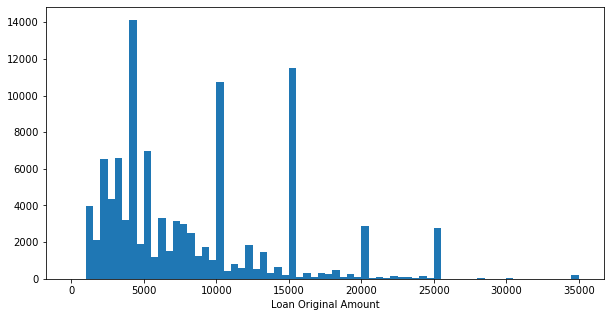

```python
x_bins = np.arange(0,new_df.LoanOriginalAmount.max()+500,500)
plt.figure(figsize=[10,5])
plt.hist(x=new_df.LoanOriginalAmount,bins=x_bins);
plt.xlabel("Loan Original Amount");
```

There are a much big spikes in different amount like 4k, 5K,10k and 15k. almost few ask for fractions and a lot ask for multiples of five

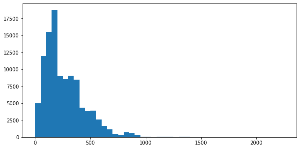

```python
x_bins = np.arange(0,new_df.MonthlyLoanPayment.max()+50,50)
plt.figure(figsize=[10,5])
plt.hist(x=new_df.MonthlyLoanPayment,bins=x_bins);
```

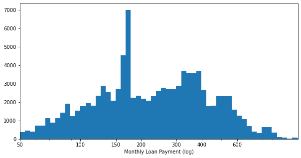

```python
x_bins = 10**np.arange(0,np.log10(new_df.MonthlyLoanPayment.max())+0.025,0.025)
plt.figure(figsize=[10,5])
plt.hist(x=new_df.MonthlyLoanPayment,bins=x_bins);
plt.xscale('log')
plt.xticks([50, 100, 150, 200, 300, 400,600], ['50', '100', '150', '200', '300', '400','600'])
plt.xlim([50,1200])
plt.xlabel("Monthly Loan Payment (log)");
```

Monthly Loan Payment has a long-tailed distribution,a lot of borrowers pay little and few pay much.When plotted in log scale the distribution is a multimodal and have a big spike between 150 to 200 and one before 400  
Next up let's see the categorical [`Term`,`LoanStatus`,`ListingCategory`,`EmploymentStatus`,`IsBorrowerHomeowner`,`CreditScore`]

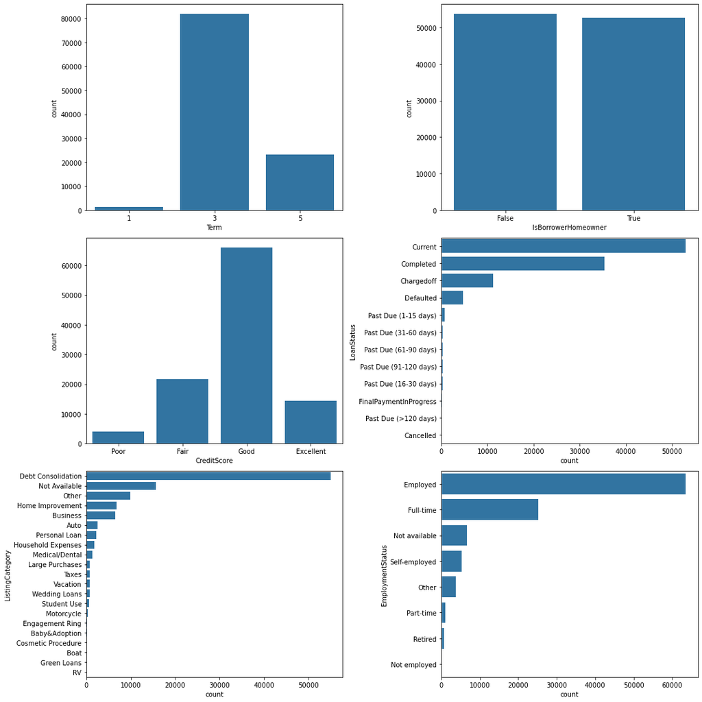

```python
fig, ax = plt.subplots(nrows=3,ncols=2, figsize = [15,15])

default_color = sb.color_palette()[0]
sb.countplot(data = new_df, x = 'Term', color = default_color, ax = ax[0,0])

sb.countplot(data = new_df, x = 'IsBorrowerHomeowner', color = default_color, ax = ax[0,1])

sb.countplot(data = new_df, x = 'CreditScore', color = default_color, ax = ax[1,0])

sb.countplot(data = new_df, y = 'LoanStatus',order=new_df.LoanStatus.value_counts().index
             ,color = default_color, ax = ax[1,1])

sb.countplot(data = new_df, y = 'ListingCategory',order=new_df.ListingCategory.value_counts().index
             , color = default_color, ax = ax[2,0])

sb.countplot(data = new_df, y = 'EmploymentStatus',order=new_df.EmploymentStatus.value_counts().index
             , color = default_color, ax = ax[2,1])

plt.tight_layout()
```

### Of the features you investigated, were there any unusual distributions? Did you perform any operations on the data to tidy, adjust, or change the form of the data? If so, why did you do this?

> When investigating the MonthlyLoanPayment a long right tail were identified so i transform to log scale and notice a big spike between 150 to 200 dollar and most loan term is 3 years term and borrowers take a Loan for Debt Consolidation in high percentage and borrowers in most are Emplyed or full time

## Bivariate Exploration

let's see the relation between `LoanStatus` and [`StatedMonthlyIncome`,`MonthlyLoanPayment`,`LoanOriginalAmount`]

```python
num_var = ['StatedMonthlyIncome','MonthlyLoanPayment','LoanOriginalAmount']
ordr = ['Current','Completed','Chargedoff','FinalPaymentInProgress','Past Due (1-15 days)','Past Due (16-30 days)'
        ,'Past Due (31-60 days)','Past Due (61-90 days)','Past Due (91-120 days)','Past Due (>120 days)','Defaulted','Cancelled']
```

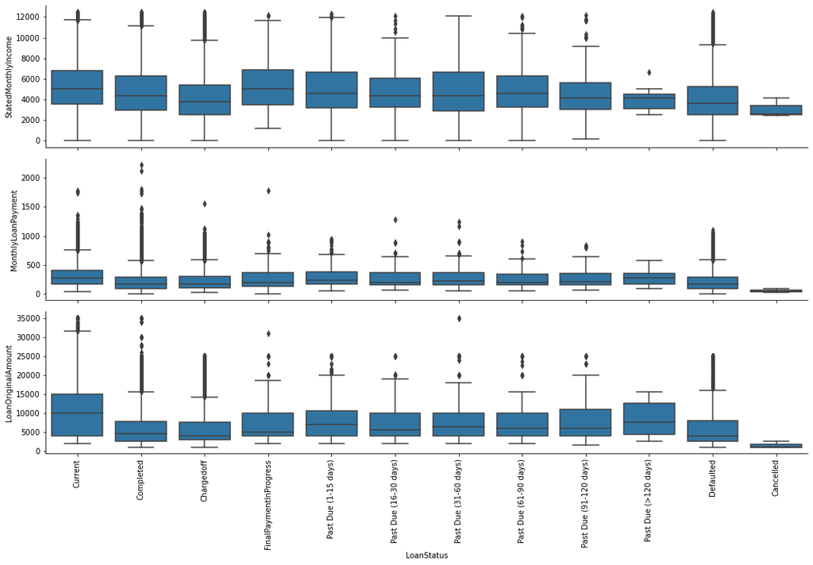

```python
def boxplott(x, y, **kwargs):
    default_color = sb.color_palette()[0]
    sb.boxplot(x, y, color = default_color,order=ordr)
    plt.xticks(rotation=90)

plt.figure(figsize = [10, 10])
g = sb.PairGrid(data = new_df, y_vars = num_var, x_vars = 'LoanStatus',
                size = 3, aspect = 5)
g.map(boxplott);
```

there is a negative correlation between monthly income and Loan status borrowers that passed their due date have a lower income but that is true from past due 1-15 days and borrowers that passed their due date > 120 days have a short distribution in monthly income and there is a slightly positive correlation that borrowers that pass their due data ask for a higher loan amount I will discover more in the next section

```python
# lets reset indexing
new_df.reset_index(inplace=True)
```

```python
new_df.drop('index',axis=1,inplace=True)
```

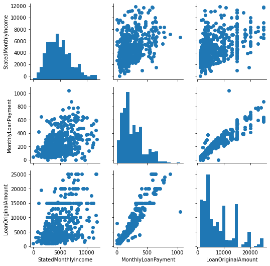

```python
# take a rondom 500 sample forom the data and loc for them by the index that why me reset the index
samples = np.random.choice(new_df.shape[0], 500, replace = False)
Loan_samp = new_df.loc[samples,:]

g = sb.PairGrid(data = Loan_samp, vars = num_var)
g = g.map_diag(plt.hist, bins = 20);
g.map_offdiag(plt.scatter);
```

there is an approximately positive linear ralation between Monthly loan amount and Loan original amount and not a big corr between monthly income and monthly loan payment

let's discover the categorical feature with the feature of interest

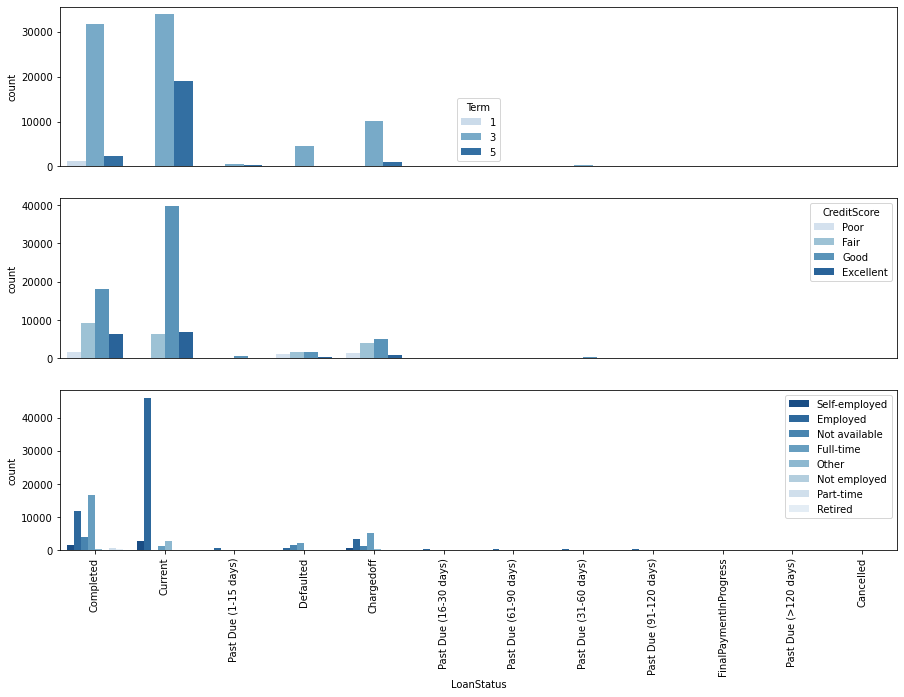

```python
fig , ax = plt.subplots(nrows=3,figsize= [15,10])

sb.countplot(data=new_df,x='LoanStatus',hue='Term',palette="Blues",ax=ax[0])
ax[0].set_xticks([])
ax[0].set_xlabel('')
sb.countplot(data=new_df,x='LoanStatus',hue='CreditScore',palette="Blues",ax=ax[1])
ax[1].set_xticks([])
ax[1].set_xlabel('')

sb.countplot(data=new_df,x='LoanStatus',hue='EmploymentStatus',palette="Blues_r",ax=ax[2])
plt.xticks(rotation = 90);
plt.legend(loc=1);
```

There doesn't seem to be that much interaction between categorical feature and Loan Status in a completed loans borrowers often borrow for 3 years and their credit score fall in most in fair and good in the current there are 3 and 5 years term and almost no loan for 1 term

lets discover the relation of categorical features [`Term`,`EmploymentStatus`,`CreditScore`]

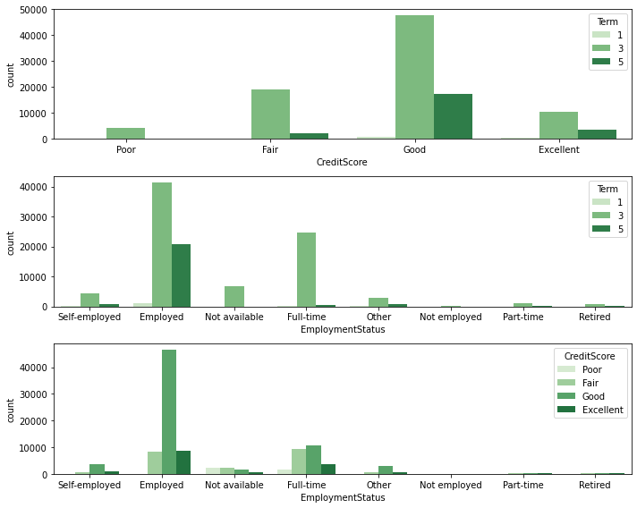

```python
fig, ax = plt.subplots(nrows=3, figsize = [10,8])

default_color = sb.color_palette()[0]
sb.countplot(data = new_df,x='CreditScore', hue = 'Term',palette='Greens', ax = ax[0])

sb.countplot(data = new_df,x='EmploymentStatus', hue = 'Term',palette='Greens',  ax = ax[1])

sb.countplot(data = new_df,x='EmploymentStatus', hue = 'CreditScore',palette='Greens', ax = ax[2])

plt.tight_layout()
```

There doesn't seem to be that much interaction between CreditScore and Term it seems like they might be more borrower loan for 3 years and they more employed and they have in much percentage good credit score

Lets discover the relation between num features[`StatedMonthlyIncome`,`MonthlyLoanPayment`,`LoanOriginalAmount`] and cat features[`Term`,`EmploymentStatus`,`CreditScore`]

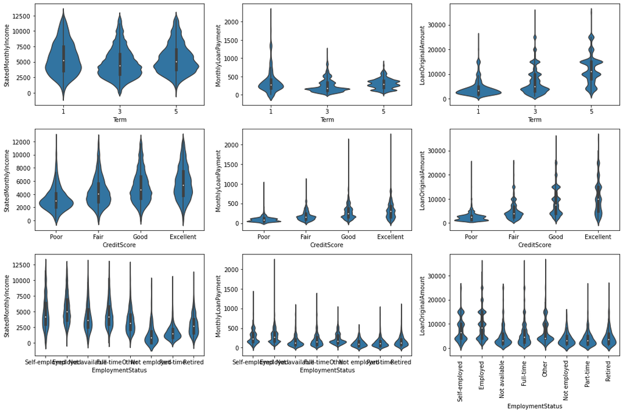

```python
cat_var = ['Term','CreditScore','EmploymentStatus']
fig , ax = plt.subplots(nrows= 3 ,ncols=3,figsize =[15,10])
for i in range(len(cat_var)):
    var = cat_var[i]
    sb.violinplot(data=new_df,x=var , y='StatedMonthlyIncome',color=default_color, ax=ax[i,0])
    sb.violinplot(data=new_df,x=var , y='MonthlyLoanPayment' ,color=default_color, ax=ax[i,1])
    sb.violinplot(data=new_df,x=var , y='LoanOriginalAmount' ,color=default_color, ax=ax[i,2])
    plt.xticks(rotation = 90)


plt.tight_layout()
```

It is not high interaction between term and monthly income, in normal higher in term lower in loan monthly payment but the plot shows that borrowers that loan for 5 years pay much every month and this because that these borrowers make a high Loan amount and it makes sense.  
there is a linear correlation in CreditScore and other numeric features and with poor credit scores borrowers pay less each month because they ask for low amounts and borrowers that not employed have a lower monthly income

### Talk about some of the relationships you observed in this part of the investigation. How did the feature(s) of interest vary with other features in the dataset?

> There is a negative correlation between monthly income and loan status in past due the lower the income, the more will be the delay in payment and their borrowers Loan a high amount  
> Most of the borrowers loan for 3 years and there is no interaction between Loan Status and term years

## Multivariate Exploration

The main thing I want to explore in this part of the analysis is how the three numerical feature play into the relationship between Loan Status and its Term.

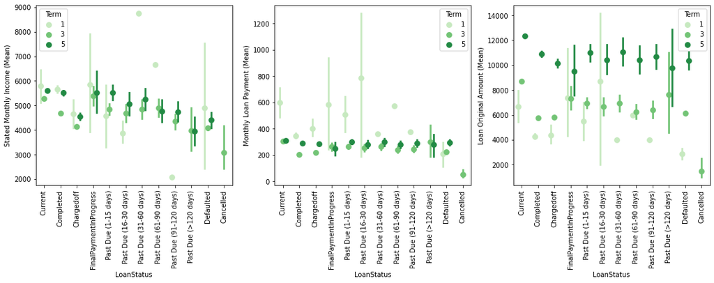

```python
fig, ax = plt.subplots(ncols = 3, figsize = [15,6])

sb.pointplot(data = new_df, x = 'LoanStatus', y = 'StatedMonthlyIncome', hue = 'Term',order=ordr,
             palette = 'Greens', linestyles = '', dodge = 0.4, ax = ax[0])
ax[0].set_ylabel('Stated Monthly Income (Mean)')
ax[0].set_yticklabels([],minor = True)
ax[0].set_xticklabels(ordr,rotation = 90)

sb.pointplot(data = new_df, x = 'LoanStatus', y = 'MonthlyLoanPayment', hue = 'Term',order=ordr,
             palette = 'Greens', linestyles = '', dodge = 0.4, ax = ax[1])
ax[1].set_ylabel('Monthly Loan Payment (Mean)')
ax[1].set_yticklabels([],minor = True)
ax[1].set_xticklabels(ordr,rotation = 90)
sb.pointplot(data = new_df, x = 'LoanStatus', y = 'LoanOriginalAmount', hue = 'Term',order=ordr,
             palette = 'Greens', linestyles = '', dodge = 0.4, ax = ax[2])
ax[2].set_ylabel('Loan Original Amount (Mean)')
ax[2].set_yticklabels([],minor = True)
ax[2].set_xticklabels(ordr,rotation = 90)

plt.tight_layout()
plt.show();
```

### Talk about some of the relationships you observed in this part of the investigation. Were there features that strengthened each other in terms of looking at your feature(s) of interest?

> There is a negative correlation between monthly income and delay lenth in repayment when borrowers ask for 1 term loan and thier income is low and the repayment is the highest in 1 year term so almost they make a delay on repayment in the defaulted status i cant see any evedince to tell me why this borrowers defaulted

### Were there any interesting or surprising interactions between features?

> More loan amount it seem that the term will be 5 years and high monthly loan payment fall into the 1 year term